# Week 11: Trees and Forests

PS 818 - Data Analysis with Statistical Models

Anton Strezhnev

strezhnev@wisc.edu

University of Wisconsin-Madison

November 16, 2026

## Trees and Forests

## Previously

- **Flexible regression**
  - Basis expansions: polynomials, step functions, splines
  - More flexibility $\leadsto$ less bias, more variance
- **Regularization**
  - Penalized regression: ridge ($L_2$) and lasso ($L_1$)
  - Penalties are priors
  - Choose the penalty by **cross-validation**
- **Many predictors**: predicting the 2020 vote in the CES with 1,898 columns

## This week

- **Trees**
  - Recursive partitioning: regression trees
- **Ensembles of trees**
  - **Bagging** and **random forests**: average many trees
  - **Boosting**: add up many small trees fit to residuals of the previous trees
  - **BART**: a sum of small trees keeping the trees small via **priors** on the tree paramters.
- **Running example**: “many predictors” in the CES survey data.

## Going forward

- **Week 12** - Flexible Regression: Kernels and Gaussian Processes
- **Week 13** - Causal Inference with Flexible Regression
- **Week 14** - Working with “Big” Datasets

## The data

- The same data as Week 10: 2020 Biden and Trump voters in the 2023 CES. 1 = Trump, 0 = Biden.

```r
ces_raw <- read_dta("../week8/data/CCES23_Common_OUTPUT.dta.gz") # the file from Week 8
ces <- ces_raw %>%
  mutate(age = 2023 - birthyr) %>%
  filter(presvote20post %in% 1:2, age <= 90) %>% # Biden or Trump voters
  mutate(trump = as.numeric(presvote20post == 2),
         w = commonweight / mean(commonweight)) # survey weights, rescaled to average 1
covs <- c("gender4", "educ", "race", "hispanic", "inputstate", "region", "urbancity", "employ", "student", "marstat",
          "child18", "ownhome", "faminc_new", "religpew", "pew_bornagain", "pew_religimp", "pew_churatd", "pew_prayer",
          "milstat_1", "milstat_3", "healthins_2", "sexuality", "immstat", "internethome",
          "CC23_300_1", "CC23_300_2", "CC23_300_3", "CC23_300_4", "CC23_305_4", "CC23_305_6")
ces_covs <- ces %>% select(all_of(covs)) %>%
  mutate(across(everything(), ~ fct_na_value_to_level(fct_drop(as_factor(.x)), "missing")))
dat <- bind_cols(ces %>% select(trump, w, age), ces_covs) %>%
  mutate(vote = factor(trump, levels = 0:1, labels = c("Biden", "Trump")))
fml <- reformulate(c("age", covs), "trump") # trump ~ age + gender4 + educ + ...
```

## The data

- Trees take the **raw** variables. No dummies, interactions, or basis functions.

```r
dim(dat)
```

```
[1] 17675    34
```

- The same 10 folds and the same (weighted) error as Week 10

```r
set.seed(53703)
folds <- sample(rep(1:10, length.out = nrow(dat)))
wmse <- function(err, w = dat$w) sum(w * err^2) / sum(w) # weighted mean squared error
cv_pred <- function(fit_fun) { # fit_fun: (train, test) -> predictions for test
  pred <- numeric(nrow(dat))
  for (k in 1:10) pred[folds == k] <- fit_fun(dat[folds != k, ], dat[folds == k, ])
  pred
}
```

## Regression trees

- A **tree** $T$ partitions the covariate space into $|T|$ non-overlapping hyper-rectangles $R_1, \dotsc, R_{|T|}$
  - These are the **leaves**
  - Each leaf predicts a **constant** $\mu_m$. Collect them in $M = (\mu_1, \dotsc, \mu_{|T|})$

  $$g(x; T, M) = \sum_{m=1}^{|T|} \mu_m \mathbf{1}(x \in R_m)$$
- For squared error, the best constant is the mean of $Y$ among the observations in the leaf: $\hat{\mu}_m = \bar{Y}_m$.
- This is a **step function**, but the regions are **chosen from the data**.
- Searching over every possible partition is computationally infeasible. Instead, trees are grown **greedily** by splitting on one variable at a time (Breiman et al. 1984).
- For an introduction aimed at political scientists, see Montgomery and Olivella (2018).

## Recursive binary splitting

- For a continuous variable $X_j$ and a cutpoint $s$, a split divides the observations into

  $$R_{\text{left}}(j, s) = \{x : x_j < s\} \quad \text{and} \quad R_{\text{right}}(j, s) = \{x : x_j \ge s\}$$
- Choose the variable **and** the cutpoint that minimize the residual sum of squares after the split:

  $$\min_{j, s} \bigg[\sum_{i: X_i \in R_{\text{left}}(j,s)} (Y_i - \bar{Y}_{\text{left}})^2 + \sum_{i: X_i \in R_{\text{right}}(j,s)} (Y_i - \bar{Y}_{\text{right}})^2\bigg]$$
- Then repeat **within** each of the two regions, and so on, until a stopping rule (e.g. a minimum number of observations per leaf).
- **Greedy**: each split is the best one available at the stage of the algorithm.
  - Can’t accept a less optimal split in one stage to get a more optimal one later.

## A regression tree on age

- Every possible cutpoint for age (all respondents)

```r
split_rss <- function(x, s, y = dat$trump, w = dat$w) { # weighted RSS after splitting x at s
  left <- x < s
  sum(w[left] * (y[left] - weighted.mean(y[left], w[left]))^2) +
    sum(w[!left] * (y[!left] - weighted.mean(y[!left], w[!left]))^2)
}
cuts <- seq(21.5, 89.5, by = 1)
rss_age <- map_dbl(cuts, ~ split_rss(dat$age, .x))
cuts[which.min(rss_age)]
```

```
[1] 46.5
```

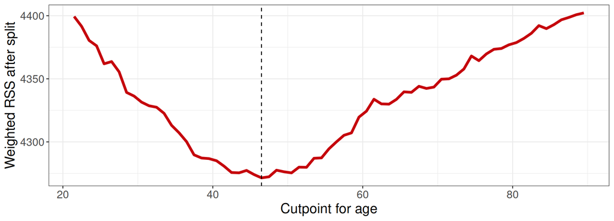

## A regression tree on age

- Keep splitting (each leaf needs at least 50 respondents), then **prune** back by cross-validation

```r
age_tree <- rpart(trump ~ age, data = dat, weights = w,
                  control = rpart.control(cp = 0, minbucket = 50, xval = folds))
age_tree <- prune(age_tree, cp = age_tree$cptable[which.min(age_tree$cptable[, "xerror"]), "CP"])
sum(age_tree$frame$var == "<leaf>") # number of leaves
```

```
[1] 17
```

- `rpart` takes our fold assignments through `xval`.

## A regression tree on age

- The tree selects a set of cutpoints **automatically**

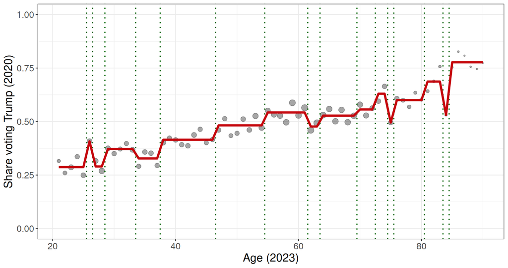

## Categorical predictors

- For a categorical variable with $L$ levels, a split allocates some levels to the left side of the tree and the rest to the right of the tree.
  - There are $2^{L-1} - 1$ ways to do this. For state ($L = 51$), that’s about $10^{15}$.
- One trick is to **sort** the levels by their mean outcome.
  - The best split is one of the $L - 1$ splits of the sorted levels (Breiman et al. 1984; Hastie, Tibshirani, and Friedman 2009).
  - `rpart` does this automatically
  - Some packages (like `grf` for random forests) don’t.
- Alternatively, just pass in all the unordered dummies (“one-hot encoding”) and let the model treat each as a distinct variable.

## One tree for Trump vote

- A regression tree for `trump` with all 31 predictors grown only two levels deep.

```r
tree2 <- rpart(fml, data = dat, weights = w, control = rpart.control(maxdepth = 2, cp = 0))
```

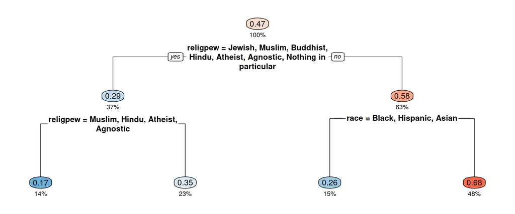

## Reading a tree

- Each box shows the share voting **Trump** and the share of respondents in the box.
- The first split is on **religious tradition**.
- The second split **depends on the first**:
  - Among Christians, the next split is **race**.
  - Among all other respondents, the next split is religious tradition **again**.
- The trees can find **interactions**
  - In this tree, race only matters as a predictor among Christians.

## One more level

```r
tree3 <- rpart(fml, data = dat, weights = w, control = rpart.control(maxdepth = 3, cp = 0))
```

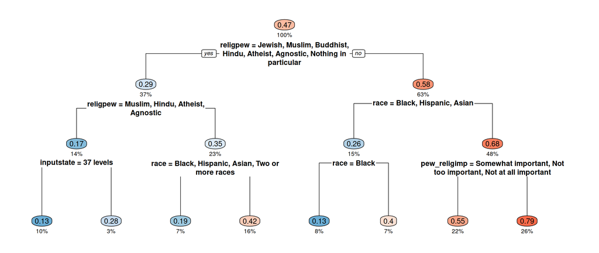

## How big should the tree be?

- We can keep splitting until every leaf is tiny.
  - Small leaves $\leadsto$ low bias, but very high variance (each leaf mean is based on a handful of respondents).
- **Cost-complexity pruning** (Breiman et al. 1984): grow a big tree $T_0$, then find the subtree $T \subseteq T_0$ that minimizes

  $$\sum_{m=1}^{|T|} \sum_{i: X_i \in R_m} (Y_i - \bar{Y}_m)^2 + \alpha |T|$$

  where $|T|$ is the number of leaves.
- Another form of penalized regression - here, the penalty is on the **number of leaves**.
  - $\alpha = 0$: the full tree. $\alpha \to \infty$: no splits at all (the intercept).
  - Choose $\alpha$ by cross-validation. `rpart` calls $\alpha / \text{RSS}_{\text{root}}$ the **complexity parameter** `cp`.

## Pruning by cross-validation

```r
big_tree <- rpart(fml, data = dat, weights = w,
                  control = rpart.control(cp = 0, minbucket = 10, xval = folds))
cp_table <- as_tibble(big_tree$cptable) %>% mutate(leaves = nsplit + 1)
cp_best <- cp_table$CP[which.min(cp_table$xerror)]
cp_table %>% slice(c(1, which.min(xerror), n())) %>% select(CP, leaves, xerror)
```

```
# A tibble: 3 × 3
       CP leaves xerror
    <dbl>  <dbl>  <dbl>
1 0.0812       1  1.00
2 0.00218     24  0.738
3 0          810  0.925
```

- `xerror` is the CV error relative to the intercept-only model. The full tree has 810 leaves. Cross-validation retains 24.

## Pruning by cross-validation

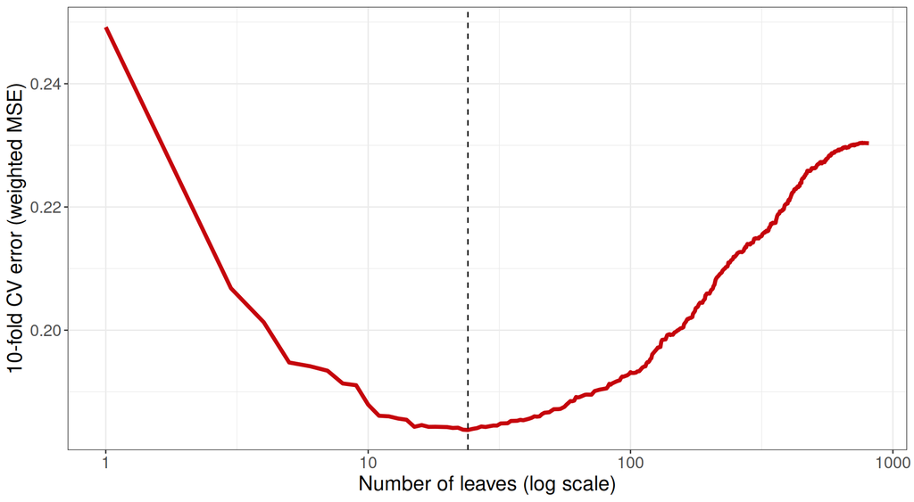

## The pruned tree

- The CV error of the pruned tree

```r
pred_tree <- cv_pred(function(train, test) {
  predict(rpart(fml, data = train, weights = w, control = rpart.control(cp = cp_best, minbucket = 10, xval = 0)), test)
})
pred_deep <- cv_pred(function(train, test) {
  predict(rpart(fml, data = train, weights = w, control = rpart.control(cp = 0, minbucket = 10, xval = 0)), test)
})
c(pruned_tree = wmse(dat$trump - pred_tree), full_tree = wmse(dat$trump - pred_deep))
```

```
pruned_tree   full_tree
      0.184       0.230
```

- The full tree overfits badly. Pruning it back to 24 leaves cuts the CV error substantially.

## Trees: pros and cons

- **Pros**
  - Small trees are easy to read and explain
  - Interactions and non-linearities are found automatically
- **Cons**
  - Step functions are a poor approximation to smooth relationships
  - **High variance**: a small change in the data can change what gets split on!

## Trees are unstable

- Growing the same tree on bootstrapped samples of the data gives different results!

```r
set.seed(818)
boot_trees <- map(1:2, function(b) {
  idx <- sample(nrow(dat), replace = TRUE)
  rpart(fml, data = dat[idx, ], weights = w, control = rpart.control(maxdepth = 2, cp = 0))
})
```

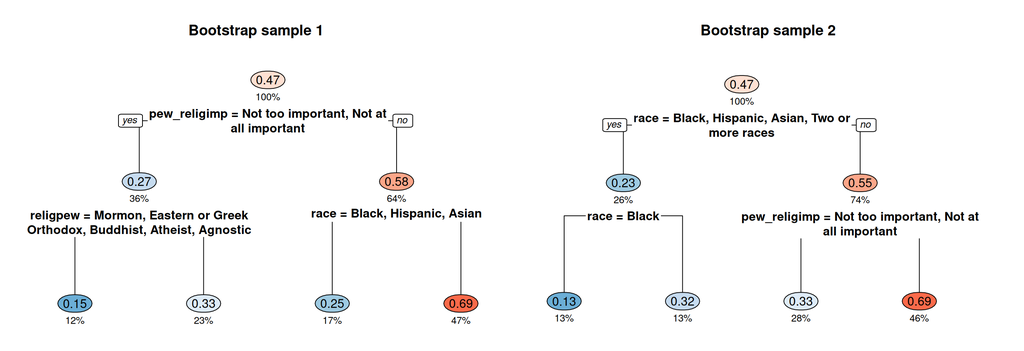

- We’re splitting first on different variables across these draws.

## Bagging

- **Bootstrap aggregation** (Breiman 1996): grow a deep tree on each of $B$ bootstrap samples, and **average** their predictions

  $$\hat{f}_{\text{bag}}(x) = \frac{1}{B}\sum_{b=1}^B \hat{f}^{*b}(x)$$
- Each tree has low bias and high variance. Averaging keeps the low bias and reduces the variance.
- How much? If each tree’s prediction has variance $\tau^2$ and any two trees have correlation $\rho$:

  $$\text{Var}\big(\hat{f}_{\text{bag}}(x)\big) = \rho \tau^2 + \frac{1 - \rho}{B}\tau^2$$
- Bagged trees are correlated
  - On every bootstrap sample, the same strong predictors (race, religion) are the ones that the method splits on first.

## Random forests

- **Random forests** (Breiman 2001): bagging plus at **each split** only a random subset of $m_{\text{try}}$ of the $p$ predictors are candidates for splits.
- Strong predictors can’t take the top split in every tree.
  - Trees are less correlated $\leadsto$ smaller $\rho$ $\leadsto$ lower variance of the average.
  - Each individual tree is worse, but the forest tends to do better.
- $m_{\text{try}}$ as a **tuning parameter** - common default is $m_{\text{try}} = p/3$
  - Also need to set the minimum **node size**

## Out-of-bag error

- Each bootstrap sample leaves out about $(1 - 1/N)^N \approx e^{-1} \approx 37\%$ of the observations.
- **Out-of-bag (OOB)** prediction: predict each observation using only the trees that it wasn’t used to estimate.
  - A built-in estimate of out-of-sample error that doesn’t need additional resampling!
  - “Cross-validation” is built in to the bootstrapping procedure.
- Alternatively, we’ll often fit each tree to a **subsample**: a random fraction of the data (e.g. half), drawn **without** replacement. Same idea, and the other half is out of bag. Why?
  - No duplicates: each tree is fit to **distinct** observations.
  - Smaller subsamples overlap less, so the trees are less correlated.
  - Subsampled forests have some nice theoretical properties for inference (Athey, Tibshirani, and Wager 2019).

## Random forests with `grf`

- `grf` (Athey, Tibshirani, and Wager 2019) fits random forests.
  - We’ll code each factor’s levels in order of their weighted mean outcome in the training data and treat those as *numeric* values that the tree can split on.

```r
encode <- function(train, newdata = train) { # numeric matrix; factor levels sorted by mean outcome in train
  map_dfc(c("age", covs), function(v) {
    if (!is.factor(newdata[[v]])) return(tibble(!!v := newdata[[v]]))
    lev_order <- train %>% group_by(lev = .data[[v]]) %>% summarize(m = weighted.mean(trump, w)) %>% arrange(m)
    tibble(!!v := match(as.character(newdata[[v]]), as.character(lev_order$lev)))
  }) %>% as.matrix()
}
X_all <- encode(dat)
rf_oob <- regression_forest(X_all, dat$trump, sample.weights = dat$w, mtry = 5, num.trees = 500,
                            honesty = FALSE, ci.group.size = 1, seed = 818)
wmse(dat$trump - predict(rf_oob)$predictions) # predict() with no new data: out-of-bag
```

```
[1] 0.162
```

- Each tree is grown on half the data, without replacement, and considers `mtry = 5` of the 31 predictors at each split.

## Random forests with `grf`

- Some `grf` options to know about:
  - `sample.weights`: used in the splits and the leaf means. `sample.fraction = 0.5`: each tree’s subsample.
  - `min.node.size = 5`: minimum node size - trees are grown deep and aren’t pruned.
  - `honesty = FALSE`: by default, `grf` grows **honest** trees, choosing the splits on one half of the subsample and estimating the leaf means on the other. Crucial for **inference**, but we’ll leave off for now.

## Random forests: choosing `mtry`

```r
rf_fit <- function(train, test, mtry) { # the factor coding is learned on the training folds only
  fit <- regression_forest(encode(train), train$trump, sample.weights = train$w, mtry = mtry, num.trees = 500,
                           honesty = FALSE, ci.group.size = 1, seed = 818)
  predict(fit, encode(train, test))$predictions
}
mtry_grid <- c(1, 3, 5, 10, 20, 31) # 31 = bagging
pred_rf_grid <- map(mtry_grid, function(m) cv_pred(function(train, test) rf_fit(train, test, m)))
rf_cv <- tibble(mtry = mtry_grid, cv_error = map_dbl(pred_rf_grid, ~ wmse(dat$trump - .x)))
rf_cv
```

```
# A tibble: 6 × 2
   mtry cv_error
  <dbl>    <dbl>
1     1    0.200
2     3    0.171
3     5    0.162
4    10    0.161
5    20    0.162
6    31    0.163
```

## Random forests: choosing `mtry`

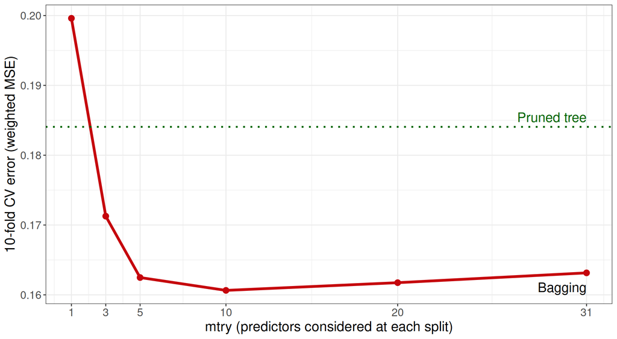

## Variable importance

- How do we figure out which predictors are “relevant” in a forest?
- **Split-based** importance: how often the trees split on $X_j$ (`grf` weights splits near the top more heavily).
- **Impurity** importance, the total reduction in RSS from splits on $X_j$.
- **Permutation** importance: randomly shuffle $X_j$ in held-out data, and measure how much the prediction error goes **up**.
  - Shuffling breaks the relationship between $X_j$ and $Y$ (and between $X_j$ and the other predictors).
- Split-based measures can be **biased** towards predictors with many possible split points (Strobl et al. 2007). Permutation importance on held-out data avoids that, but it’s noisier. Correlated predictors can also stand in for each other when one is shuffled.

## Variable importance

- Permutation importance on fold 1, for a forest grown on folds 2-10

```r
mtry_best <- rf_cv$mtry[which.min(rf_cv$cv_error)]
train <- dat[folds != 1, ]; test <- dat[folds == 1, ]
rf_imp <- regression_forest(encode(train), train$trump, sample.weights = train$w, mtry = mtry_best,
                            num.trees = 500, honesty = FALSE, ci.group.size = 1, seed = 818)
X_test <- encode(train, test)
err_test <- wmse(test$trump - predict(rf_imp, X_test)$predictions, test$w)
set.seed(818)
imp <- list(split = setNames(variable_importance(rf_imp)[, 1], colnames(X_test)),
            permutation = map_dbl(set_names(colnames(X_test)), function(v) {
              X_perm <- X_test; X_perm[, v] <- sample(X_perm[, v]) # shuffle one predictor
              wmse(test$trump - predict(rf_imp, X_perm)$predictions, test$w) - err_test
            }))
```

## Variable importance

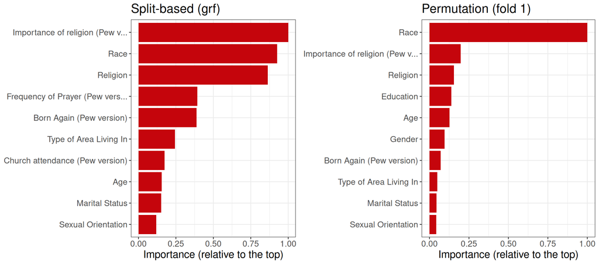

- Both agree on the top three: race, the importance of religion, and religious tradition.

## Partial dependence

- How do we plot the relationship between predictor and outcome? There’s no coefficient to interpret!
- The **partial dependence** of $f$ on age (Friedman 2001): set **everyone’s** age to $a$, predict, and average

  $$\bar{f}_{\text{age}}(a) = \frac{1}{N} \sum_{i=1}^N \hat{f}(a, X_{i,-\text{age}})$$
- Partial dependence is **standardization**: the same formula as the back-door adjustment in causal inference (Zhao and Hastie 2021).
  - If the other predictors block every back-door path from age to the vote, it’s the causal effect of age.
  - But some predictors are **post-treatment** to age!
- We’ll rarely interpret these causally, but they can be useful diagnostic tools!

## Partial dependence

```r
rf_full <- regression_forest(X_all, dat$trump, sample.weights = dat$w, mtry = mtry_best, num.trees = 500,
                             honesty = FALSE, ci.group.size = 1, seed = 818)
set.seed(60639)
pd_sample <- sample(nrow(dat), 2000) # average over 2,000 respondents to save time
pd_ages <- seq(21, 90, by = 3)
pd_rf <- map_dbl(pd_ages, function(a) {
  X_pd <- X_all[pd_sample, ]; X_pd[, "age"] <- a # everyone gets age a
  weighted.mean(predict(rf_full, X_pd)$predictions, dat$w[pd_sample])
})
```

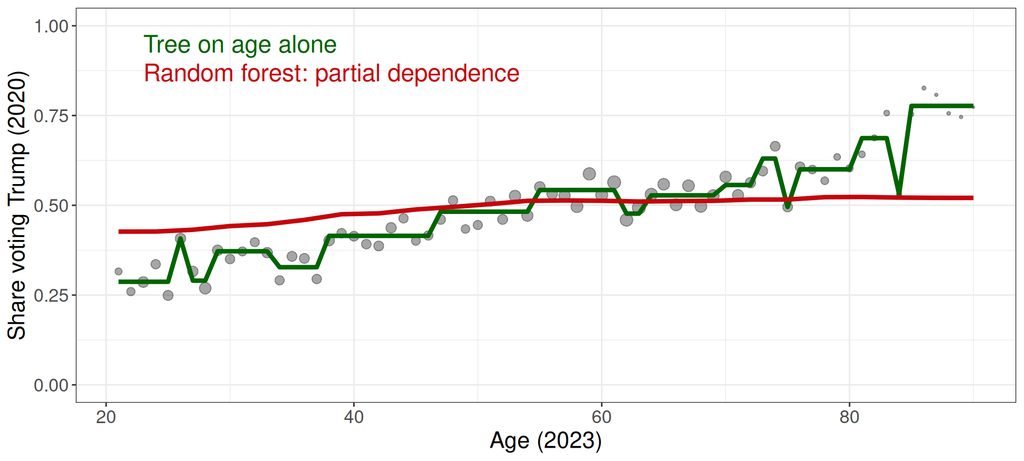

## Boosting

- Bagging and random forests grow trees **independently** and average them.
- **Boosting** grows trees **sequentially**. Each tree is fit to whatever the previous trees **didn’t explain** (James et al. 2013):
  1. Start with $\hat{f}(x) = \bar{Y}$ and residuals $r_i = Y_i - \bar{Y}$.
  2. For $b = 1, \dotsc, B$:
     - Fit a **small** tree $\hat{f}^b(x) = g(x; \hat{T}_b, \hat{M}_b)$ (depth $d$) to the residuals $r$
     - Update $\hat{f}(x) \leftarrow \hat{f}(x) + \nu \hat{f}^b(x)$ and $r_i \leftarrow r_i - \nu \hat{f}^b(X_i)$
  3. The fit is $\hat{f}(x) = \bar{Y} + \nu \sum_{b=1}^B g(x; \hat{T}_b, \hat{M}_b)$
- Three tuning parameters:
  - $B$, the number of trees. Unlike random forests, boosting **overfits** if $B$ is too large.
  - $\nu$, the **shrinkage** - how much should each tree contribute to the prediction, typically $0.01$ to $0.1$.
  - $d$, the depth of each tree

## Boosting

- Train on folds 2-10 and keep fold 1 as a test set. Depth-2 trees, $\nu = 0.1$, $B = 300$

```r
train <- dat[folds != 1, ]; test <- dat[folds == 1, ]
nu <- 0.1; B <- 300
fit_train <- rep(weighted.mean(train$trump, train$w), nrow(train))
fit_test <- rep(weighted.mean(train$trump, train$w), nrow(test))
boost_trees <- list(); err_train <- err_test <- numeric(B)
for (b in 1:B) {
  train$r <- train$trump - fit_train # current residuals
  boost_trees[[b]] <- rpart(update(fml, r ~ .), data = train, weights = w,
                            control = rpart.control(maxdepth = 2, cp = 0, xval = 0))
  fit_train <- fit_train + nu * predict(boost_trees[[b]], train)
  fit_test <- fit_test + nu * predict(boost_trees[[b]], test)
  err_train[b] <- wmse(train$trump - fit_train, train$w)
  err_test[b] <- wmse(test$trump - fit_test, test$w)
}
```

## Boosting: the first two trees

- The first tree fits the outcome. The second tree fits to what the first tree didn’t explain.

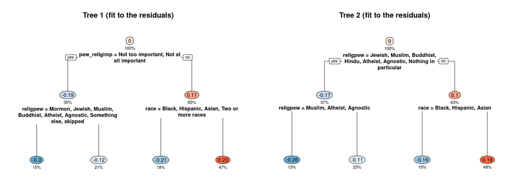

## Boosting: later trees

- Later trees fit to what the main predictors fail to explain.

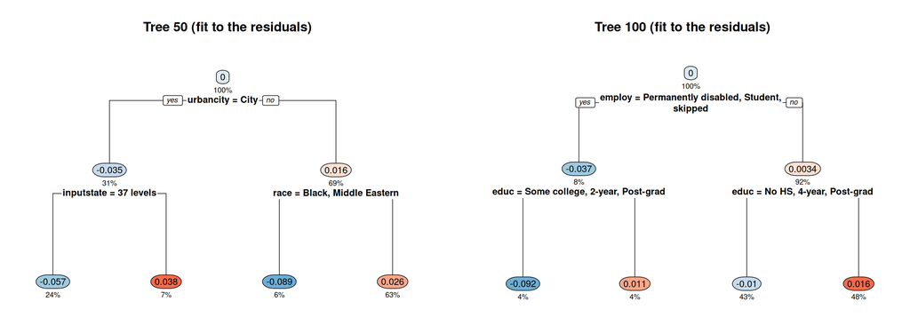

## Boosting: error

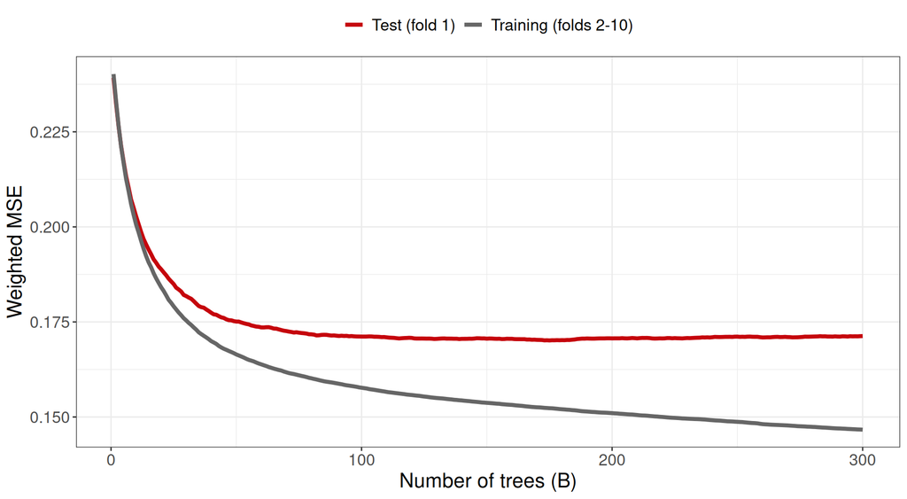

## Boosting and regularization

- Each step moves the fit a **small** amount in the direction of a single tree.
- Boosting is regularized in two ways:
  - **Shrinkage**: $\nu < 1$ means no single tree takes over.
  - **Early stopping**: $B$ chosen by cross-validation.
- **Gradient boosting** (Friedman 2001) replaces the residuals with the negative gradient of any loss function: the log-likelihood of a logit for binary outcomes, a Poisson for counts, etc.
  - For a normal regression model, the negative gradient **is** the residual.

## Boosting with `gbm`

- `gbm` grows each tree on a random half of the training data (`bag.fraction = 0.5`). Depth $d \in \{1, 3, 6\}$, up to 2,000 trees, $\nu = 0.05$

```r
ntree_grid <- seq(50, 2000, by = 50)
gbm_cv <- function(depth) {
  pred <- matrix(NA, nrow(dat), length(ntree_grid))
  for (k in 1:10) {
    train <- dat[folds != k, ]
    set.seed(818)
    fit <- gbm(fml, data = train, weights = w, distribution = "gaussian", n.trees = 2000,
               interaction.depth = depth, shrinkage = 0.05, bag.fraction = 0.5, n.minobsinnode = 10)
    pred[folds == k, ] <- predict(fit, dat[folds == k, ], n.trees = ntree_grid)
  }
  pred
}
pred_gbm <- map(c(1, 3, 6), gbm_cv)
gbm_err <- map_dfr(set_names(pred_gbm, c(1, 3, 6)), .id = "depth",
                   ~ tibble(trees = ntree_grid, cv_error = apply(.x, 2, function(p) wmse(dat$trump - p))))
gbm_err %>% group_by(depth) %>% slice_min(cv_error)
```

```
# A tibble: 3 × 3
# Groups:   depth [3]
  depth trees cv_error
  <chr> <dbl>    <dbl>
1 1      1800    0.171
2 3       600    0.165
3 6       300    0.163
```

## Boosting with `gbm`

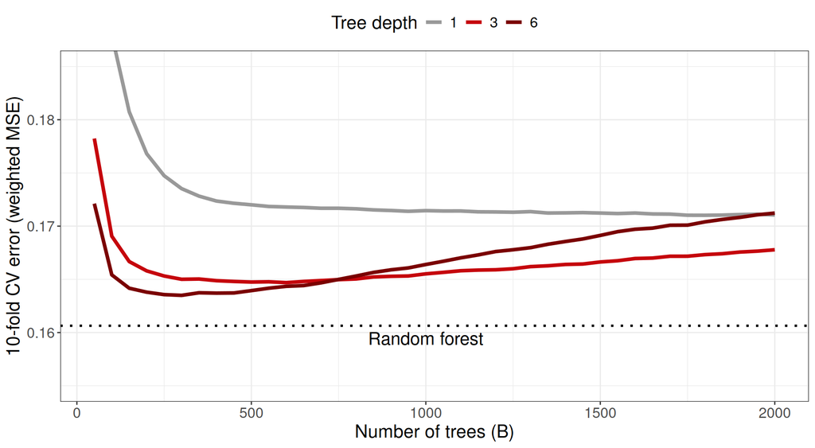

## Bayesian Additive Regression Trees

- **BART** (Chipman, George, and McCulloch 2010) is also a sum of small trees, but with a full **probability model**:

  $$Y_i = \sum_{b=1}^{B} g(X_i; T_b, M_b) + \epsilon_i, \quad \epsilon_i \sim \text{Normal}(0, \sigma^2)$$
  - Each $g(\cdot\,; T_b, M_b)$ is a tree as before: $T_b$ is its structure (the splits) and $M_b$ the values $\mu_m$ in its leaves.
- Instead of a learning rate and early stopping, **priors** keep each tree small and avoid having one tree dominate the fit:
  - A node at depth $d$ splits with prior probability $0.95(1 + d)^{-2}$. Most trees have 2 or 3 leaves (prior probability $\approx 0.83$).
  - Leaf values are regularized with a $\text{Normal}(0, \sigma^2_\mu)$ prior. $\sigma_\mu$ shrinks as the number of trees $B$ grows (more regularization to counter more flexibility from additional trees)
  - A scaled inverse-$\chi^2$ prior on $\sigma^2$.
- **Penalties are priors**: the tree prior prunes and the leaf prior shrinks.

## Fitting BART

- MCMC by **Bayesian backfitting**: a Gibbs sampler that updates one tree at a time, given the **partial residuals** of the other $B - 1$ trees.
  - Like boosting, each tree is fit to what the others miss.
  - New tree structures are proposed (grow a leaf, prune a split, change a split rule) and accepted or rejected with Metropolis-Hastings.
- For a binary outcome, use a **probit** link: $\Pr(Y_i = 1 | X_i) = \Phi\big(\sum_b g(X_i; T_b, M_b)\big)$, with a latent normal variable for each observation.
- The output is a set of **posterior draws** of $f(x)$, so we get uncertainty for any prediction or summary of the fit.
- The default priors tend to work well (Chipman, George, and McCulloch 2010; Hill, Linero, and Murray 2020).

## BART with `dbarts`

- Check the sampler: 4 chains on the full data, tracking a few **functions** of the fit

```r
bart_chains <- bart(as.data.frame(dat[, c("age", covs)]), dat$trump, x.test = as.data.frame(dat[1:3, c("age", covs)]),
                    ntree = 200, nskip = 500, ndpost = 1000, nchain = 4, nthread = 4, combinechains = FALSE,
                    verbose = FALSE, seed = 818)
avg_share <- apply(pnorm(bart_chains$yhat.train), c(1, 2), weighted.mean, w = dat$w) # chain x draw
n_splits <- apply(bart_chains$varcount, c(1, 2), sum)                                  # splits across all 200 trees
draws <- array(c(t(avg_share), aperm(pnorm(bart_chains$yhat.test), c(2, 1, 3)), t(n_splits)), dim = c(1000, 4, 5),
               dimnames = list(NULL, NULL, c("avg_share", "resp_1", "resp_2", "resp_3", "n_splits")))
rm(bart_chains) # the full set of draws is large
```

## BART: traceplots

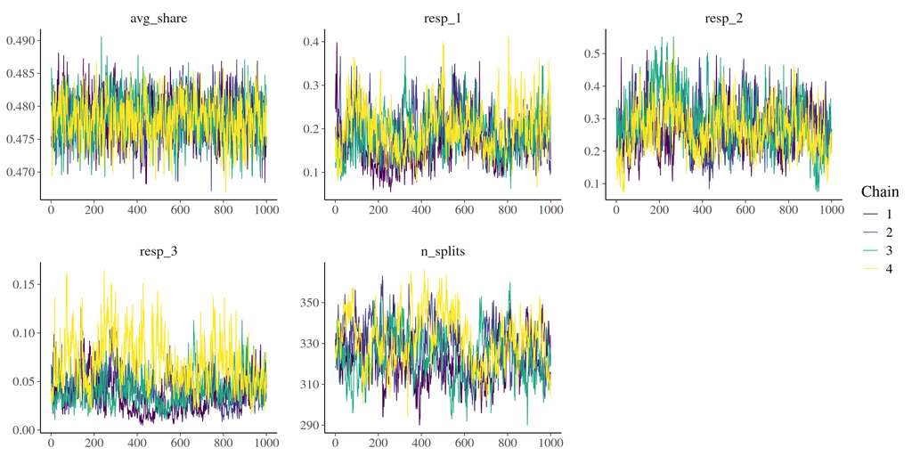

## BART: convergence diagnostics

- $\hat{R}$ and effective sample sizes

```r
bart_diag <- posterior::summarise_draws(posterior::as_draws_array(draws), "mean",
                                        ~ posterior::quantile2(.x, probs = c(.025, .975)), "rhat", "ess_bulk", "ess_tail")
bart_diag %>% kable(digits = 3)
```

| variable | mean | q2.5 | q97.5 | rhat | ess_bulk | ess_tail |
| --- | --- | --- | --- | --- | --- | --- |
| avg_share | 0.478 | 0.472 | 0.484 | 1.01 | 610.0 | 2052.5 |
| resp_1 | 0.187 | 0.097 | 0.299 | 1.06 | 73.7 | 166.8 |
| resp_2 | 0.276 | 0.148 | 0.433 | 1.05 | 115.5 | 214.3 |
| resp_3 | 0.047 | 0.014 | 0.106 | 1.23 | 12.5 | 31.3 |
| n_splits | 326.377 | 304.000 | 351.000 | 1.09 | 33.2 | 136.6 |

## Reading the diagnostics

- The average predicted share mixes well: $\hat{R}$ = 1.01, and 610 effective draws out of 4,000.
- Individual predictions and the number of splits mix much more **slowly**: $\hat{R}$ up to 1.23, and as few as 13 effective draws.
  - Each tree changes by one small step (grow, prune, change a rule) per iteration, so the tree structures explore the posterior slowly.
  - Credible intervals for **individual** respondents would need longer, or more, chains.

## BART: cross-validated error

```r
bart_fit <- function(train, test) {
  fit <- bart(as.data.frame(train[, c("age", covs)]), train$trump, x.test = as.data.frame(test[, c("age", covs)]),
              ntree = 200, nskip = 500, ndpost = 1000, verbose = FALSE, seed = 818)
  colMeans(pnorm(fit$yhat.test)) # yhat is on the probit scale: average Pr(Y = 1) over posterior draws
}
pred_bart <- cv_pred(bart_fit)
wmse(dat$trump - pred_bart)
```

```
[1] 0.161
```

- 200 trees, 500 burn-in and 1,000 posterior draws, and the default priors.

## BART: partial dependence with uncertainty

```r
bart_full <- bart(as.data.frame(dat[, c("age", covs)]), dat$trump, ntree = 200, nskip = 500, ndpost = 1000,
                  verbose = FALSE, seed = 818, keeptrees = TRUE)
pd_bart <- map_dfr(pd_ages, function(a) {
  newdata <- as.data.frame(dat[pd_sample, c("age", covs)]) %>% mutate(age = a)
  draws <- predict(bart_full, newdata, type = "ev") %*% dat$w[pd_sample] / sum(dat$w[pd_sample]) # one PD per draw
  tibble(age = a, est = mean(draws), lo = quantile(draws, .025), hi = quantile(draws, .975))
})
```

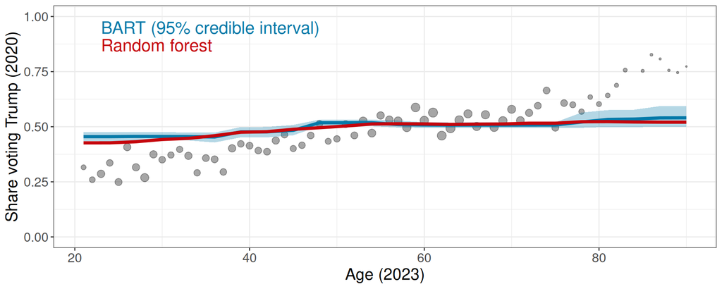

## Comparing everything

| Method | CV error | CV accuracy |
| --- | --- | --- |
| Intercept only | 0.2492 | 53.0% |
| Least squares, 1,898 columns (Week 10) | 0.1917 | 73.6% |
| Ridge (Week 10) | 0.1692 | 75.8% |
| Lasso (Week 10) | 0.1667 | 75.8% |
| Single tree, pruned by CV | 0.1841 | 72.6% |
| Bagging (mtry = 31) | 0.1631 | 76.3% |
| Random forest (mtry = 10) | 0.1606 | 76.9% |
| Boosting (depth 6) | 0.1635 | 75.9% |
| BART | 0.1607 | 76.3% |

- Same 10 folds for every method. Accuracy: predict Trump when the predicted probability is above 0.5.
- Tuning parameters ($\lambda$, `cp`, `mtry`, $B$ and $d$) were chosen by the **same** CV error, so every row is a bit optimistic.

## Summary

- **Trees** partition the predictors into rectangles and predict a constant in each.
  - No assumptions on functional form - enough splits can uncover deep interactions.
  - Interpretable, but high variance.
  - And risk overfitting if grown too deep!
- **Ensembles** sacrifice interpretability for greater accuracy:
  - **Averages of trees**: Grow many deep trees on bootstrap samples and average the predictions
    - De-correlate them by using subsets of predictors at each split
  - **Sums of trees** - Grow many small trees and add them together.
    - Each tree explains a different part of the outcome.
    - **BART**: Regularization through Bayesian priors on the tree parameters

## Next week

- **Flexible regression: kernels and Gaussian processes**
  - Infinite-dimensional function spaces
  - Kernel ridge regression
  - Gaussian process regression: a prior over **functions**
- Class meets Monday. Wednesday is cancelled for Thanksgiving.
- **Readings**: Hainmueller and Hazlett (2014); Chapters 2 and 4 of Rasmussen and Williams (2006)

## References

Athey, Susan, Julie Tibshirani, and Stefan Wager. 2019. “Generalized Random Forests.” *The Annals of Statistics* 47 (2): 1148–78. https://doi.org/10.1214/18-AOS1709.

Breiman, Leo. 1996. “Bagging Predictors.” *Machine Learning* 24 (2): 123–40. https://doi.org/10.1007/BF00058655.

———. 2001. “Random Forests.” *Machine Learning* 45 (1): 5–32. https://doi.org/10.1023/A:1010933404324.

Breiman, Leo, Jerome H. Friedman, Richard A. Olshen, and Charles J. Stone. 1984. *Classification and Regression Trees*. Belmont, CA: Wadsworth.

Chipman, Hugh A., Edward I. George, and Robert E. McCulloch. 2010. “BART: Bayesian Additive Regression Trees.” *The Annals of Applied Statistics* 4 (1): 266–98. https://doi.org/10.1214/09-AOAS285.

Friedman, Jerome H. 2001. “Greedy Function Approximation: A Gradient Boosting Machine.” *The Annals of Statistics* 29 (5): 1189–1232. https://doi.org/10.1214/aos/1013203451.

Hainmueller, Jens, and Chad Hazlett. 2014. “Kernel Regularized Least Squares: Reducing Misspecification Bias with a Flexible and Interpretable Machine Learning Approach.” *Political Analysis* 22 (2): 143–68. https://doi.org/10.1093/pan/mpt019.

Hastie, Trevor, Robert Tibshirani, and Jerome Friedman. 2009. *The Elements of Statistical Learning: Data Mining, Inference, and Prediction*. 2nd ed. New York: Springer. https://doi.org/10.1007/978-0-387-84858-7.

Hill, Jennifer, Antonio Linero, and Jared Murray. 2020. “Bayesian Additive Regression Trees: A Review and Look Forward.” *Annual Review of Statistics and Its Application* 7: 251–78. https://doi.org/10.1146/annurev-statistics-031219-041110.

James, Gareth, Daniela Witten, Trevor Hastie, and Robert Tibshirani. 2013. *An Introduction to Statistical Learning*. New York: Springer. https://doi.org/10.1007/978-1-4614-7138-7.

Montgomery, Jacob M., and Santiago Olivella. 2018. “Tree-Based Models for Political Science Data.” *American Journal of Political Science* 62 (3): 729–44. https://doi.org/10.1111/ajps.12361.

Rasmussen, Carl Edward, and Christopher K. I. Williams. 2006. *Gaussian Processes for Machine Learning*. Cambridge, MA: MIT Press.

Strobl, Carolin, Anne-Laure Boulesteix, Achim Zeileis, and Torsten Hothorn. 2007. “Bias in Random Forest Variable Importance Measures: Illustrations, Sources and a Solution.” *BMC Bioinformatics* 8: 25. https://doi.org/10.1186/1471-2105-8-25.

Zhao, Qingyuan, and Trevor Hastie. 2021. “Causal Interpretations of Black-Box Models.” *Journal of Business & Economic Statistics* 39: 272–81. https://doi.org/10.1080/07350015.2019.1624293.